# Sun King Insights Data Task

Abigail Nzambi

2026-03-30

# Part 1, Section A: Exploratory Data Analysis

## 1. Compute the total sales for Area A and Area B over the three months.

Table 1: Total units sold by area within the 3 months

| Area | Total units sold | Percentage units sold |
| --- | --- | --- |
| Area A | 2935 | 76.39 |
| Area B | 907 | 23.61 |

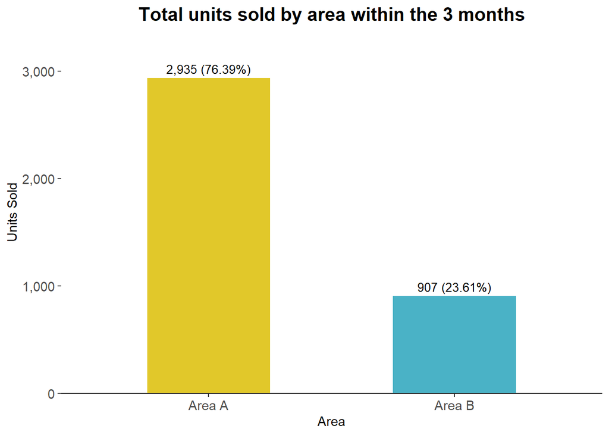

Between December 2023 and February 2024, a total of 3,842 units were sold across both areas. Area A accounted for the majority of sales, with 2,935 units (76.39%), while Area B recorded 907 units (23.61%). Area A outsold Area B by more than three to one over the three-month period.

## 2. Determine the total sales per product group for the two areas. How do the two areas compare?

Table 2: Total units sold by area and product group within the 3 months

| Area | Product Group | Total Units Sold | Percentage Units Sold |
| --- | --- | --- | --- |
| Area A | Product 1 | 2503 | 85.28 |
| Area A | Product 3 | 264 | 8.99 |
| Area A | Product 2 | 67 | 2.28 |
| Area A | Product 5 | 54 | 1.84 |
| Area A | Product 4 | 25 | 0.85 |
| Area A | Product 7 | 15 | 0.51 |
| Area A | Product 6 | 7 | 0.24 |
| Area B | Product 1 | 594 | 65.49 |
| Area B | Product 2 | 133 | 14.66 |
| Area B | Product 3 | 108 | 11.91 |
| Area B | Product 5 | 35 | 3.86 |
| Area B | Product 4 | 16 | 1.76 |
| Area B | Product 7 | 12 | 1.32 |
| Area B | Product 6 | 9 | 0.99 |

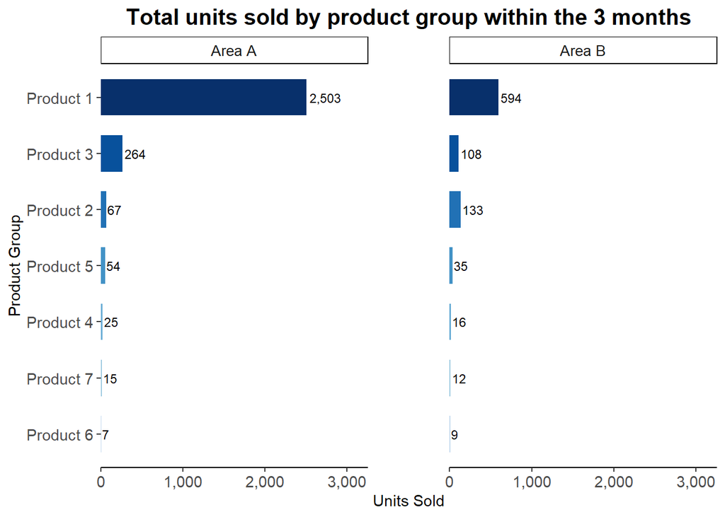

## 3. What is the most popular product in Area A? What is the proportion of the best-seller relative to all sales in the area?

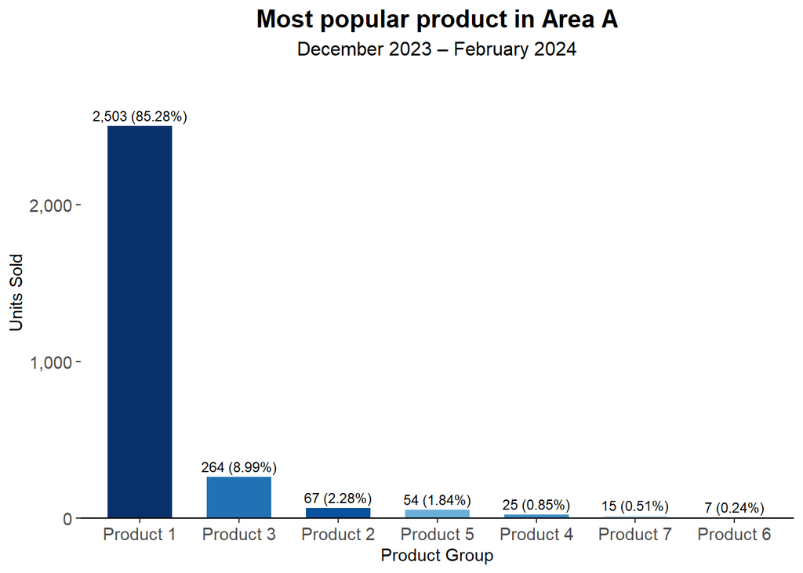

Product 1 is the most popular product in Area A, with 2,503 units sold, representing 85.28% of all Area A sales, with the remaining six product groups collectively accounting for only 14.72% of sales.

## 4a. How many units of Product 1 were sold on December 13, 2023, in Area A?

On December 13, 2023, 30 units of Product 1 were sold in Area A.

## 4b. How many units of Product 5 were sold in Area B in January 2024?

In January 2024, 15 units of Product 5 were sold in Area B.

# Part 2, Question 1

## Power Calculation to Determine Sample Size

The following assumptions were used to determine the required sample size:

[output not shown]

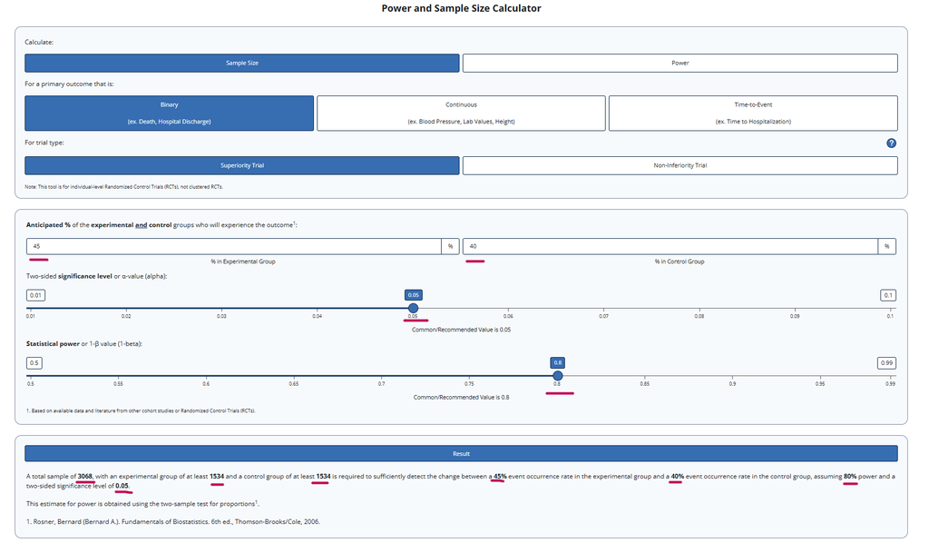

Power Calculation Result